# Watershed dealineation with the macrosheds package

Delineation requires only latitude and longitude, and can be done interactively.

Mike Vlah

Step 1: load the `macrosheds` package.

*See the ms_retrieval_flux_calc vignette for an introduction to the package.*

```r
library(macrosheds)
```

We use `elevatr` to retrieve digital elevation models (DEMs) and WhiteboxTools for DEM conditioning, pour point snapping, flow accumulation, and delineation itself. The `whitebox` package requires binaries that aren’t shipped with the CRAN package, but you can install them like so:

```r
whitebox::install_whitebox()
```

```
## WhiteboxTools binary is located here:  /home/weston/R/x86_64-pc-linux-gnu-library/4.2/whitebox/WBT/whitebox_tools
```

## Delineation without prior information

To delineate a watershed with no prior knowledge of its area, road density, etc., you don’t need to supply many arguments. Just latitude, longitude, and their coordinate reference system. If you don’t know the CRS, try 4326 (WGS 84). If you run this as-is, it’ll create a new folder called ‘my_watershed_boundaries’ in your home directory. Feel free to change that.

```r
    out <- ms_delineate_watershed(
        lat = 44.21013,
        long = -122.2571,
        crs = 4326,
        write_dir = '~/my_watershed_boundaries',
        write_name = 'example_site'
    )
```

Now you might want to scan around the edges and verify that the delineator hasn’t stopped at any bridges or dams. If it has, you can try again with “S”, which burns streams into the DEM. If you’re satisfied, type “2” and hit [enter].

Of course you’d see the watershed interactively during the delineation, but here’s how you can load the shapefile afterward and and view it.

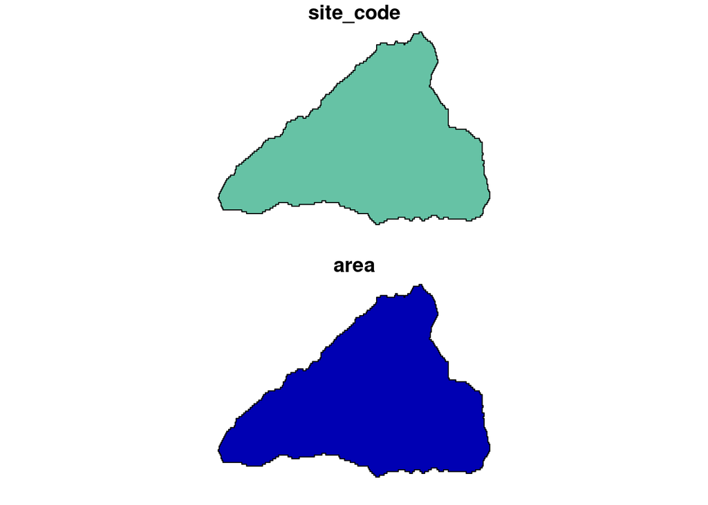

```r
library(sf)
st_read('~/my_watershed_boundaries/example_site.shp', quiet = TRUE) %>%
    plot()
```

And here are the contents of `out`:

```
$out_path
[1] "~/my_watershed_boundaries"

$filename_base
[1] "example_site"

$watershed_area_ha
[1] 6219.831

$deets
$deets$name
[1] "example_site"

$deets$buffer_radius_m
[1] 1000

$deets$snap_distance_m
[1] 150

$deets$snap_method
[1] "standard"

$deets$dem_resolution
[1] 10

$deets$flat_increment
[1] "null"

$deets$breach_method
[1] "basic"

$deets$burn_streams
[1] FALSE
```

It includes the path to the shapefile, the watershed area, and all the specifications of the successful delineation.

## Delineation with partial information

If you knew in advance that a watershed was on the order of 50,000 hectares, you could start with a larger DEM than the default. By default, a DEM will be downloaded that covers the circle defined by the buffer radius. So for a watershed of 50,000 ha, you’d have a radius of ~11,000 meters (`sqrt(5e8) / 2`). You could specify `buffer_radius_m = 11000`. If this still isn’t large enough (if the delineation reaches the edge of the DEM), a larger DEM will be retrieved automatically.

Any parameter you specify won’t have to be searched, so specify whatever you can. Of course, some parameters like `flat_increment` and `snap_method` aren’t very intuitive. It’s fine to omit any parameters too.

## Delineation with complete information

If you were to run the delineation above again for whatever reason, you wouldn’t want to wait for the first attempt before specifying the parameters that get the job done. You can glean these by looking at the output above. Let’s specify them all, and since we already know the outcome of this run, there’s no need to be prompted for anything–let’s set `confirm = FALSE`.

```r
    out <- ms_delineate_watershed(
        lat = 44.21013,
        long = -122.2571,
        crs = 4326,
        write_dir = '~/my_watershed_boundaries',
        write_name = 'example_site',
        spec_buffer_radius_m = 1000,
        spec_snap_distance_m = 150,
        spec_snap_method = 'standard',
        spec_dem_resolution = 10,
        spec_flat_increment = NULL,
        spec_breach_method = 'basic',
        verbose = FALSE,
        confirm = FALSE
    )
```

```
##
 Accessing raster elevation [-------------------------]   0%
 Accessing raster elevation [=========================] 100%
## Mosaicing & Projecting
```

```
## fill_single_cell_pits - Elapsed Time (excluding I/O): 0.1s
## breach_depressions - Elapsed Time (excluding I/O): 0.37s
## d8_pointer - Elapsed Time (excluding I/O): 0.2s
## d8_flow_accumulation - Elapsed Time (excluding I/O): 0.9s
## snap_pour_points - Elapsed Time (excluding I/O): 0.0s
## watershed - Elapsed Time (excluding I/O): 0.6s
```

```
## Delineation successful and confirm == FALSE. Writing shapefile to ~/my_watershed_boundaries
```